# Movies Analysis

Francisco Castillo, Fernanda Esquivel y Andrés Montoya

29/01/2024

```r
movies <- read.csv("data/movies.csv")
```

# 1. Haga una exploración rápida de sus datos, para eso haga un resumen de su conjunto de datos.

```r
summary(movies)
```

```
##        id             budget             genres            homePage
##  Min.   :     5   Min.   :        0   Length:10000       Length:10000
##  1st Qu.: 12286   1st Qu.:        0   Class :character   Class :character
##  Median :152558   Median :   500000   Mode  :character   Mode  :character
##  Mean   :249877   Mean   : 18551632
##  3rd Qu.:452022   3rd Qu.: 20000000
##  Max.   :922260   Max.   :380000000
##  productionCompany  productionCompanyCountry productionCountry
##  Length:10000       Length:10000             Length:10000
##  Class :character   Class :character         Class :character
##  Mode  :character   Mode  :character         Mode  :character
##
##
##
##     revenue             runtime        video           director
##  Min.   :0.000e+00   Min.   :  0.0   Mode :logical   Length:10000
##  1st Qu.:0.000e+00   1st Qu.: 90.0   FALSE:9430      Class :character
##  Median :1.631e+05   Median :100.0   TRUE :84        Mode  :character
##  Mean   :5.674e+07   Mean   :100.3   NA's :486
##  3rd Qu.:4.480e+07   3rd Qu.:113.0
##  Max.   :2.847e+09   Max.   :750.0
##     actors          actorsPopularity   actorsCharacter    originalTitle
##  Length:10000       Length:10000       Length:10000       Length:10000
##  Class :character   Class :character   Class :character   Class :character
##  Mode  :character   Mode  :character   Mode  :character   Mode  :character
##
##
##
##     title           originalLanguage     popularity        releaseDate
##  Length:10000       Length:10000       Min.   :    4.258   Length:10000
##  Class :character   Class :character   1st Qu.:   14.578   Class :character
##  Mode  :character   Mode  :character   Median :   21.906   Mode  :character
##                                        Mean   :   51.394
##                                        3rd Qu.:   40.654
##                                        Max.   :11474.647
##     voteAvg         voteCount      genresAmount    productionCoAmount
##  Min.   : 1.300   Min.   :    1   Min.   : 0.000   Min.   : 0.000
##  1st Qu.: 5.900   1st Qu.:  120   1st Qu.: 2.000   1st Qu.: 2.000
##  Median : 6.500   Median :  415   Median : 3.000   Median : 3.000
##  Mean   : 6.483   Mean   : 1342   Mean   : 2.596   Mean   : 3.171
##  3rd Qu.: 7.200   3rd Qu.: 1316   3rd Qu.: 3.000   3rd Qu.: 4.000
##  Max.   :10.000   Max.   :30788   Max.   :16.000   Max.   :89.000
##  productionCountriesAmount  actorsAmount    castWomenAmount
##  Min.   :  0.000           Min.   :     0   Length:10000
##  1st Qu.:  1.000           1st Qu.:    13   Class :character
##  Median :  1.000           Median :    21   Mode  :character
##  Mean   :  1.751           Mean   :  2148
##  3rd Qu.:  2.000           3rd Qu.:    36
##  Max.   :155.000           Max.   :919590
##  castMenAmount
##  Length:10000
##  Class :character
##  Mode  :character
##
##
##
```

# 2. Diga el tipo de cada una de las variables (cualitativa ordinal o nominal, cuantitativa continua, cuantitativa discreta)

```
- Id: Cuantitativa discreta
- popularity: Cuantitativa continua
- budget: Cuantitativa continua
- revenue: Cuantitativa continua
- original_title: Cualitativa nominal
- originalLanguage: Cualitatitva nominal
- title: Cualitativa nominal
- homePage: Cualitativa nominal
- video: Cualitatitva nominal
- director: Cualitatitva nominal
- runtime: Cuantitativa continua
- genres: Cualitatitva nominal
- genresAmount: Cuantitativa discreta
- productionCompany: Cualitativa nominal
- productionCoAmount: Cuantitativa discreta
- productionCompanyCountry: Cualitativa nominal
- productionCountry: Cualitativa nominal
- productionCountriesAmount: Cuantitativa discreta
- releaseDate: Cualitativa nominal
- voteCount: Cuantitativa discreta
- voteAvg: Cuantitativa continua
- actors: Cualitativa nominal
- actorsPopularity: Cuantitativa continua
- actorsCharacter: Cualitativa nominal
- actorsAmount: Cuantitativa discreta
- castWomenAmount: Cuantitativa discreta
- castMenAmount: Cuantitativa discreta
```

# 3. Investigue si las variables cuantitativas siguen una distribución normal y haga una tabla de frecuencias de las variables cualitativas.

## Variables cuantitativas

### Budget

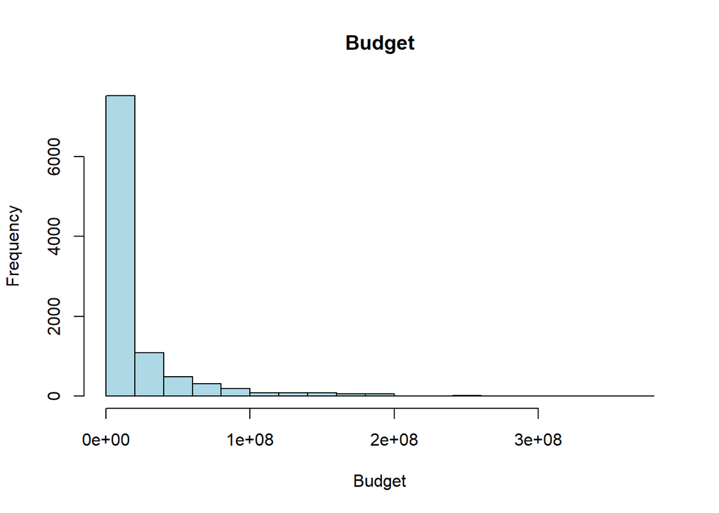

```r
hist(movies$budget, col = "lightblue", main = "Budget", xlab = "Budget")
```

### Revenue

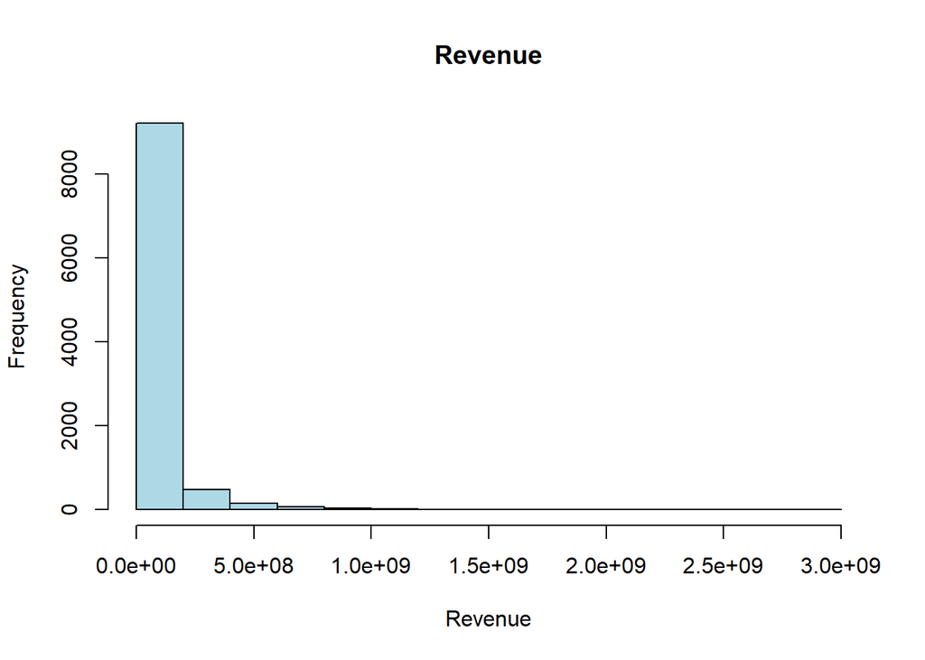

```r
hist(movies$revenue, col = "lightblue", main = "Revenue", xlab = "Revenue")
```

### Runtime

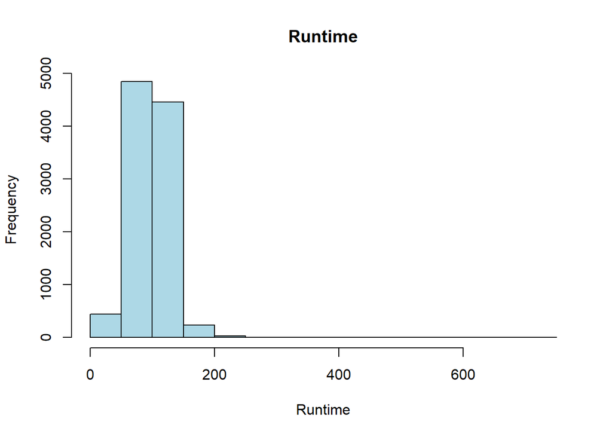

```r
hist(movies$runtime, col = "lightblue", main = "Runtime", xlab = "Runtime")
```

### Popularity

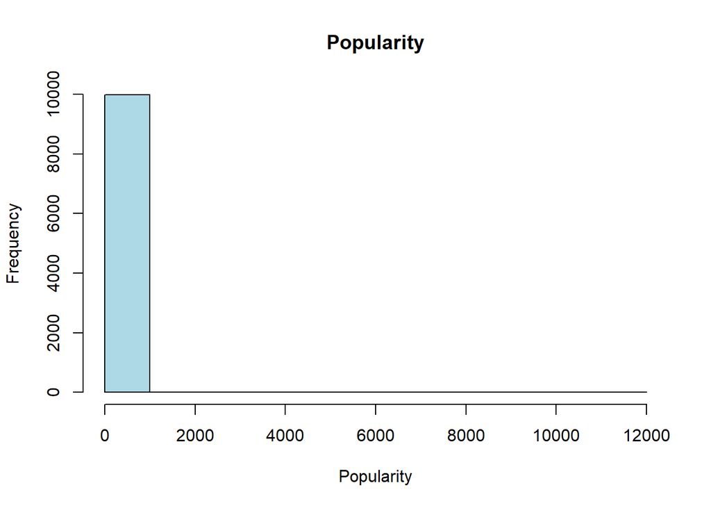

```r
hist(movies$popularity, col = "lightblue", main = "Popularity", xlab = "Popularity")
```

### Vote Average

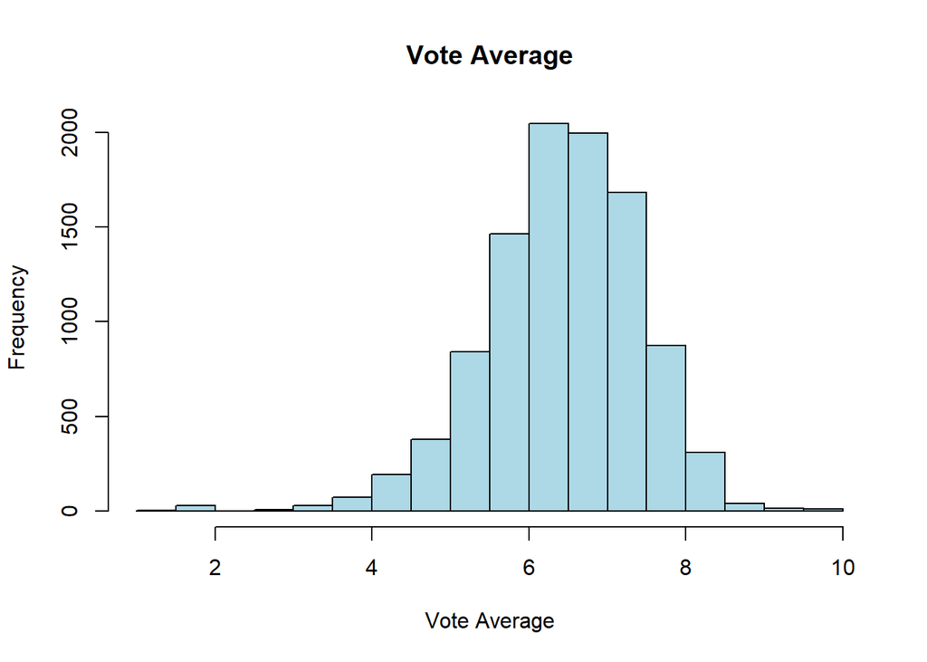

```r
hist(movies$voteAvg, col = "lightblue", main = "Vote Average", xlab = "Vote Average")
```

### Vote Count

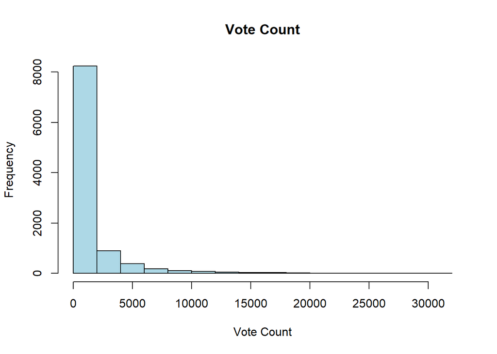

```r
hist(movies$voteCount, col = "lightblue", main = "Vote Count", xlab = "Vote Count")
```

### Genres Amount

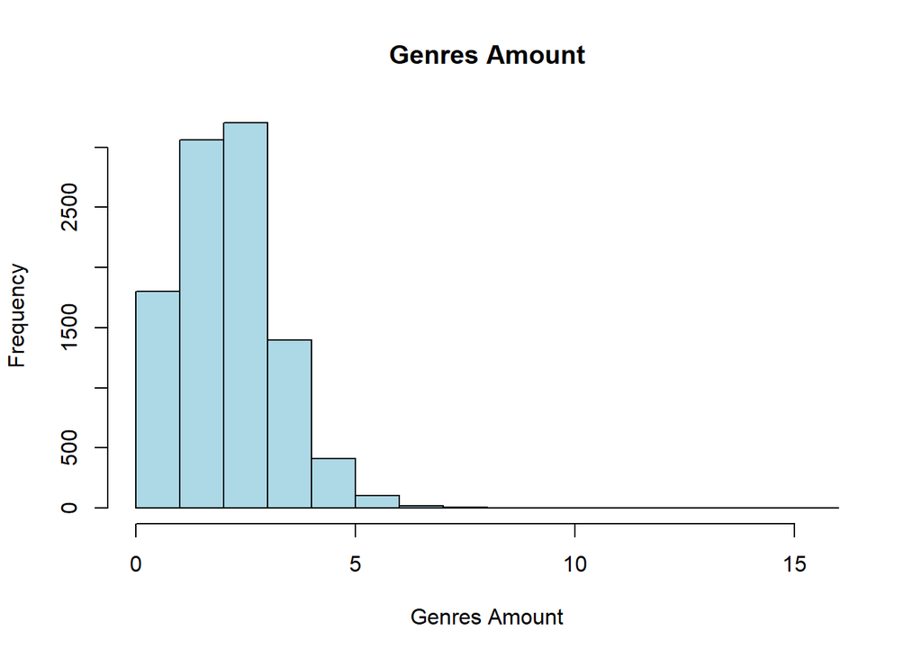

```r
hist(movies$genresAmount, col = "lightblue", main = "Genres Amount", xlab = "Genres Amount")
```

### Production Companies Amount

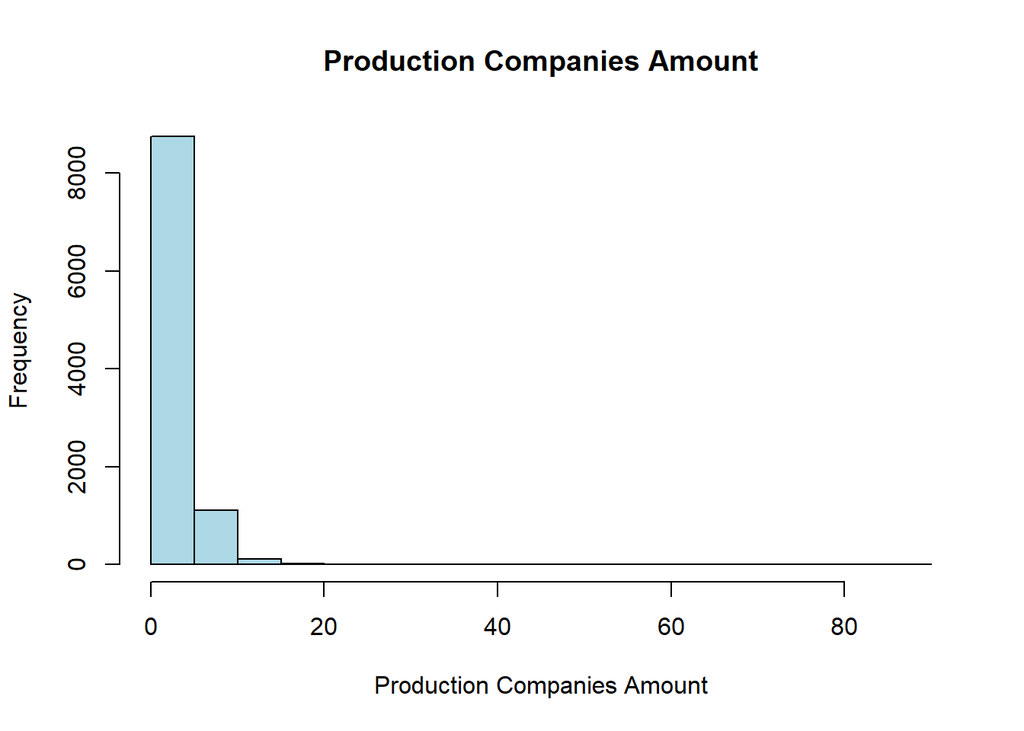

```r
hist(movies$productionCoAmount, col = "lightblue", main = "Production Companies Amount", xlab = "Production Companies Amount")
```

### Production Countries Amount

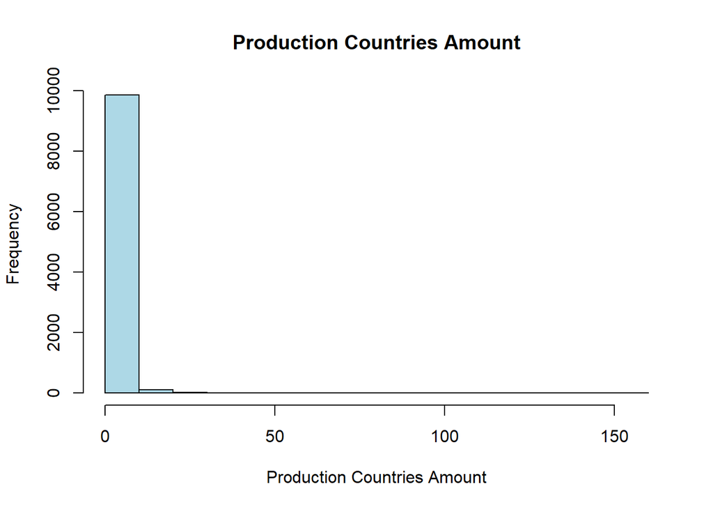

```r
hist(movies$productionCountriesAmount, col = "lightblue", main = "Production Countries Amount", xlab = "Production Countries Amount")
```

### Actors Amount

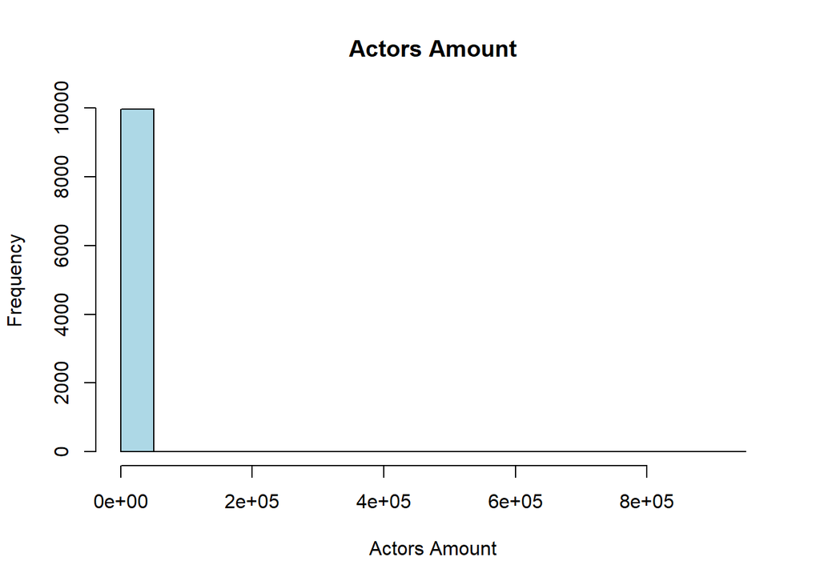

```r
hist(movies$actorsAmount, col = "lightblue", main = "Actors Amount", xlab = "Actors Amount")
```

### Cast Women Amount

```r
movies$int_cast_women_amount <- as.integer(movies$castWomenAmount)
```

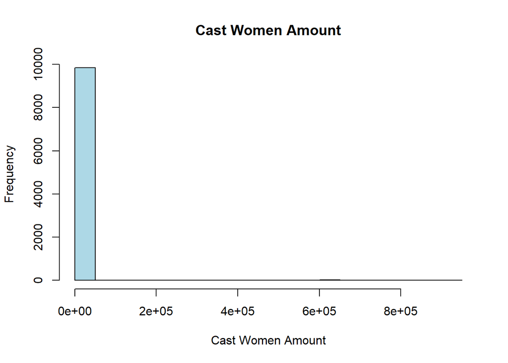

```r
hist(movies$int_cast_women_amount, col = "lightblue", main = "Cast Women Amount", xlab = "Cast Women Amount")
```

### Cast Men Amount

```r
movies$int_cast_men_amount <- as.integer(movies$castMenAmount)
```

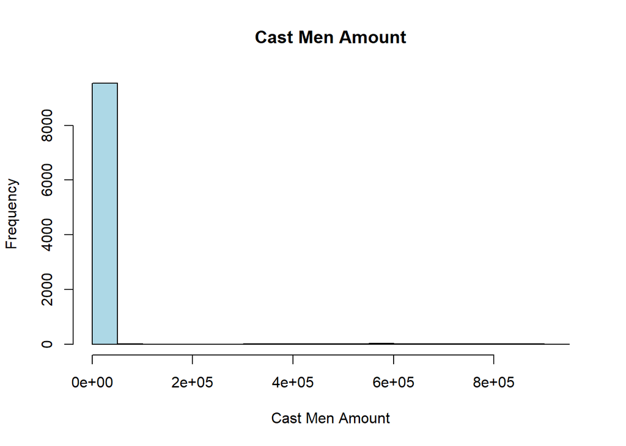

```r
hist(movies$int_cast_men_amount, col = "lightblue", main = "Cast Men Amount", xlab = "Cast Men Amount")
```

## Variables cualitativas

### Genres

```r
split_genres <- strsplit(movies$genres, "|", fixed = TRUE)
genres <- unlist(split_genres)
genres_freq <- table(genres)
genres_freq_table <- as.data.frame(genres_freq)
colnames(genres_freq_table) <- c("Genres", "Frequency")
print(genres_freq_table)
```

```
##             Genres Frequency
## 1           Action      2632
## 2        Adventure      1769
## 3        Animation      1460
## 4           Comedy      3018
## 5            Crime      1225
## 6      Documentary       299
## 7            Drama      3789
## 8           Family      1407
## 9          Fantasy      1284
## 10         History       406
## 11          Horror      1512
## 12           Music       315
## 13         Mystery       804
## 14         Romance      1428
## 15 Science Fiction      1267
## 16        Thriller      2565
## 17        TV Movie       276
## 18             War       275
## 19         Western       120
```

### Production Companies

```r
split_prod_company <- strsplit(movies$productionCompany, "|", fixed = TRUE)
prod_company <- unlist(split_prod_company)
prod_company_freq <- table(prod_company)
prod_company_freq_table <- as.data.frame(prod_company_freq)
colnames(prod_company_freq_table) <- c("Production Companies", "Frequency")
print(tail(prod_company_freq_table, n = 10))
```

```
##                                  Production Companies Frequency
## 8993                            Zookeeper Productions         2
## 8994                                        Zoom (KR)         2
## 8995 Zoom Hunt International Productions Company Ltd.         1
## 8996                                      Zorya Films         1
## 8997                      Zucker Brothers Productions         1
## 8998                               Zucker Productions         1
## 8999                                         Zut Film         1
## 9000                                     Zwart Arbeid         2
## 9001                                       ZXY MOVIES         1
## 9002                                     Zygote Films         1
```

### Production Company Countries

```r
split_prod_company_country <- strsplit(movies$productionCompanyCountry, "|", fixed = TRUE)
prod_company_country <- unlist(split_prod_company_country)
prod_company_country_freq <- table(prod_company_country)
prod_company_country_freq_table <- as.data.frame(prod_company_country_freq)
colnames(prod_company_country_freq_table) <- c("Production Companies Countries", "Frequency")
print(head(prod_company_country_freq_table, n = 10))
```

```
##    Production Companies Countries Frequency
## 1                                      5991
## 2                              AE        22
## 3                              AR        92
## 4                       Argentina         1
## 5                              AT        23
## 6                              AU       189
## 7                              BA         2
## 8                              BE       255
## 9                              BG        20
## 10                             BO         1
```

### Production Countries

```r
split_prod_country <- strsplit(movies$productionCountry, "|", fixed = TRUE)
prod_country <- unlist(split_prod_country)
prod_country_freq <- table(prod_country)
prod_country_freq_table <- as.data.frame(prod_country_freq)
colnames(prod_country_freq_table) <- c("Production Countries", "Frequency")
print(head(prod_country_freq_table, n = 10))
```

```
##    Production Countries Frequency
## 1           Afghanistan         1
## 2               Albania         2
## 3               Algeria         1
## 4                Angola         1
## 5            Antarctica         1
## 6             Argentina        70
## 7                 Aruba         2
## 8             Australia       188
## 9               Austria        25
## 10              Bahamas         2
```

### Video

```r
video_freq <- table(movies$video)
video_freq_table <- as.data.frame(video_freq)
colnames(video_freq_table) <- c("Video", "Frequency")
print(video_freq_table)
```

```
##   Video Frequency
## 1 FALSE      9430
## 2  TRUE        84
```

### Director

```r
split_director <- strsplit(movies$director, "|", fixed = TRUE)
director <- unlist(split_director)
director_freq <- table(director)
director_freq_table <- as.data.frame(director_freq)
colnames(director_freq_table) <- c("Director", "Frequency")
print(tail(director_freq_table, n = 10))
```

```
##              Director Frequency
## 5483      Zhang Yimou         8
## 5484      Zhang Zhiyi         1
## 5485          Zhao Ji         2
## 5486        Zhong Ren         1
## 5487      Zhou Jiuqin         1
## 5488    Ziggy Hofmeyr         1
## 5489 Zoe Lister-Jones         2
## 5490   Zoie Nagelhout         1
## 5491     Zoltan Korda         1
## 5492        Zu Quirke         1
```

### Actors

```r
split_actors <- strsplit(movies$actors, "|", fixed = TRUE)
actors <- unlist(split_actors)
actors_freq <- table(actors)
actors_freq_table <- as.data.frame(actors_freq)
colnames(actors_freq_table) <- c("Actors", "Frequency")
print(tail(actors_freq_table, n = 10))
```

```
##                   Actors Frequency
## 83631       Zuhdi Boueri         1
## 83632        Zulay Henao         8
## 83633     Zuleyka Silver         1
## 83634   Zulhaila Siregar         1
## 83635     Zuli Silawanto         1
## 83636      Zully Montero         1
## 83637    Zuraya Hamilton         1
## 83638 Zuzanna Szadkowski         1
## 83639      Zvonimir Hace         1
## 83640  Zygmunt Jozefczak         1
```

### Actors Character

```r
split_actors_character <- strsplit(movies$actorsCharacter, "|", fixed = TRUE)
actors_character <- unlist(split_actors_character)
actors_character_freq <- table(actors_character)
actors_character_freq_table <- as.data.frame(actors_character_freq)
colnames(actors_character_freq_table) <- c("Actors Character", "Frequency")
print(tail(actors_character_freq_table, n = 10))
```

```
##                 Actors Character Frequency
## 140924                      Zuzu         1
## 140925                  Zvetlana         1
## 140926               Zvi Aharoni         1
## 140927                   Zway-Lo         1
## 140928 Zwaylo Boy 2 (uncredited)         1
## 140929                   Zwirner         1
## 140930  Zydeco Singer at Funeral         1
## 140931                     Zygon         2
## 140932                     Zylak         1
## 140933           Zylak's Frenemy         1
```

### Original title

```r
original_title_freq <- table(movies$originalTitle)
original_title_freq_table <- as.data.frame(original_title_freq)
colnames(original_title_freq_table) <- c("Original Title", "Frequency")
print(head(original_title_freq_table, n = 10))
```

```
##                                                                                               Original Title
## 1                                                                             Una pel\xedcula de polic\xedas
## 2                                                                                  El sexo de los \xe1ngeles
## 3                                                                                             S\xed, Mi Amor
## 4                                                                          Devoto, la invasi\xf3n silenciosa
## 5                                                                   Daisy Quokka: World\x92s Scariest Animal
## 6                                                                               Cet obscur objet du d\xe9sir
## 7                                                                                         Destello Brav\xedo
## 8                         劇場版 HUNTER\xd7HUNTER 緋色の幻影
## 9  サニー\xb7サイド\xb7バトル!!!, Sani Saido Batoru!!!
## 10                                                           Catalina la Catrina: especial D\xeda de Muertos
##    Frequency
## 1          1
## 2          1
## 3          1
## 4          1
## 5          1
## 6          1
## 7          1
## 8          1
## 9          1
## 10         1
```

### Title

```r
title_freq <- table(movies$title)
title_freq_table <- as.data.frame(title_freq)
colnames(title_freq_table) <- c("Title", "Frequency")
print(head(title_freq_table, n = 10))
```

```
##                                                               Title Frequency
## 1  Hakuoki - Demon of the Fleeting Blossom \x96 Wild Dance of Kyoto         1
## 2              Dragon Ball Z: Broly \x96 The Legendary Super Saiyan         1
## 3                                      Pok\xe9mon Detective Pikachu         1
## 4                              Franco Escamilla: Por La An\xe9cdota         1
## 5                                                           Mam\xe1         1
## 6                                                        Ma m\xe8re         1
## 7                                                    Le Samoura\xef         1
## 8        Pirates of the Caribbean: Tales of the Code \x96 Wedlocked         1
## 9                                                        Ranma \xbd         1
## 10                    Matando Cabos 2: La M\xe1scara del M\xe1scara         1
```

### Original Language

```r
original_language_freq <- table(movies$originalLanguage)
original_language_freq_table <- as.data.frame(original_language_freq)
colnames(original_language_freq_table) <- c("Original Language", "Frequency")
print(original_language_freq_table)
```

```
##    Original Language Frequency
## 1                 ar         1
## 2                 bn         1
## 3                 ca         1
## 4                 cn        80
## 5                 cs         2
## 6                 da        27
## 7                 de        84
## 8                 el         2
## 9                 en      7772
## 10                es       425
## 11                eu         1
## 12                fa         3
## 13                fi         8
## 14                fr       271
```

[output cut: 26 more lines]

### Release Date

```r
release_date_freq <- table(movies$releaseDate)
release_date_freq_table <- as.data.frame(release_date_freq)
colnames(release_date_freq_table) <- c("Release Date", "Frequency")
print(head(release_date_freq_table, n = 10))
```

```
##    Release Date Frequency
## 1    1902-04-17         1
## 2    1920-02-27         1
## 3    1921-01-21         1
## 4    1922-02-17         1
## 5    1925-07-12         1
## 6    1925-12-24         1
## 7    1926-12-25         1
## 8    1927-02-06         1
## 9    1927-04-07         1
## 10   1929-06-05         1
```

Respecto a los histogramas de las variables cuantitativas, se puede observar que muy pocas de ellas sigue una distribución normal. Las variables que siguen una distribución normal son: Run Time, Vote Average y Genres Amount. De estas variables, Run Time y Genres Amount cuentan con una distribución asimétrica positiva. Las variables de Vote Average y Genres Amount poseen una curtosis mesocúrtica, mientras que Run Time posee una curtosis leptocúrtica.

En el caso de las variables cualitativas, se puede observar que existen variables como Home Page que su frecuencia no aporta información relevante, por lo que se decidió no incluirla en este análisis. Pero puede ser útil para un análisis más profundo cuando se investigue de forma individual cada variable.

# 4. Preguntas

## 4.1 ¿Cuáles son las 10 películas que contaron con más presupuesto?

```r
movies <- movies[order(movies$budget, decreasing = TRUE), ]
top_10_budget <- head(movies, 10)
top_10_budget <- top_10_budget[, c("title", "budget")]
print(top_10_budget)
```

```
##                                            title    budget
## 717  Pirates of the Caribbean: On Stranger Tides 380000000
## 4711                     Avengers: Age of Ultron 365000000
## 5953                           Avengers: Endgame 356000000
## 164     Pirates of the Caribbean: At World's End 300000000
## 4954                              Justice League 300000000
## 5954                      Avengers: Infinity War 300000000
## 608                             Superman Returns 270000000
## 3792                                     Tangled 260000000
## 7135                               The Lion King 260000000
## 281                                 Spider-Man 3 258000000
```

## 4.2 ¿Cuáles son las 10 películas que más ingresos tuvieron?

```r
movies <- movies[order(movies$revenue, decreasing = TRUE), ]
top_10_revenue <- head(movies, 10)
top_10_revenue <- top_10_revenue[, c("title", "revenue")]
print(top_10_revenue)
```

```
##                             title    revenue
## 3211                       Avatar 2847246203
## 5953            Avengers: Endgame 2797800564
## 308                       Titanic 2187463944
## 4948 Star Wars: The Force Awakens 2068223624
## 5954       Avengers: Infinity War 2046239637
## 4915               Jurassic World 1671713208
## 7135                The Lion King 1667635327
## 9050      Spider-Man: No Way Home 1631853496
## 3398                 The Avengers 1518815515
## 5088                    Furious 7 1515047671
```

## 4.3 ¿Cuál es la película que más votos tuvo?

```r
movies <- movies[order(movies$voteCount, decreasing = TRUE), ]
top_1_vote_count <- head(movies, 1)
top_1_vote_count <- top_1_vote_count[, c("title", "voteCount")]
print(top_1_vote_count)
```

```
##          title voteCount
## 3512 Inception     30788
```

## 4.4 ¿Cuál es la peor película de acuerdo a los votos de todos los usuarios?

```r
movies <- movies[order(movies$voteAvg, decreasing = FALSE), ]
top_1_vote_avg <- head(movies, 1)
top_1_vote_avg <- top_1_vote_avg[, c("title", "voteAvg")]
print(top_1_vote_avg)
```

```
##                                                                                 title
## 9787 DAKAICHI -I'm Being Harassed by the Sexiest Man of the Year- The Movie: In Spain
##      voteAvg
## 9787     1.3
```

## 4.5 ¿Cuántas películas se hicieron en cada año? ¿En qué año se hicieron más películas? Haga un gráfico de barras

```r
movies$releaseDate <- as.Date(movies$releaseDate)
movies$year <- format(movies$releaseDate, "%Y")
movies_per_year <- table(movies$year)
movies_per_year_table <- as.data.frame(movies_per_year)
colnames(movies_per_year_table) <- c("Year", "Movies")
print(movies_per_year_table)
```

```
##    Year Movies
## 1  1902      1
## 2  1920      1
## 3  1921      1
## 4  1922      1
## 5  1925      2
## 6  1926      1
## 7  1927      2
## 8  1929      1
## 9  1930      1
## 10 1931      4
## 11 1932      1
## 12 1933      1
## 13 1935      1
## 14 1936      1
```

[output cut: 85 more lines]

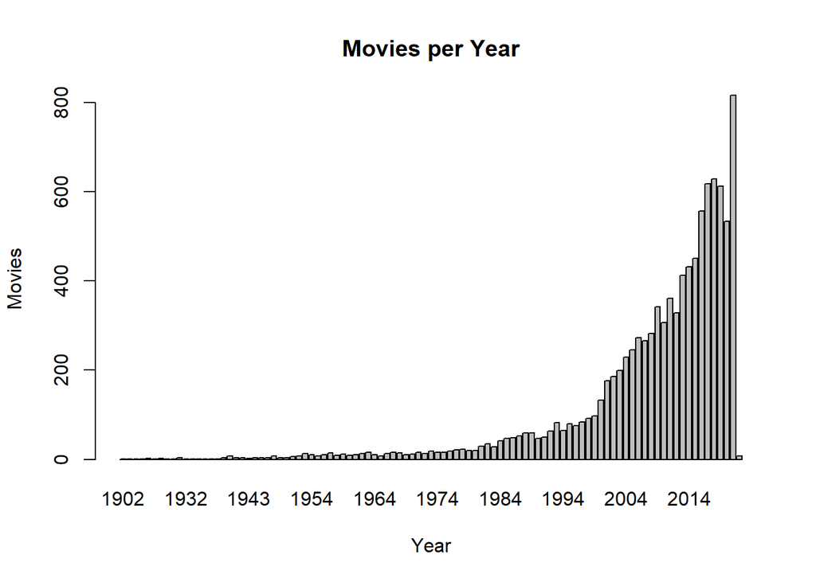

```r
barplot(movies_per_year, main = "Movies per Year", xlab = "Year", ylab = "Movies")
```

## 4.6 ¿Cuál es el género principal de las 20 películas más recientes? ¿Cuál es el género principal que predomina en el conjunto de datos? Represéntelo usando un gráfico

```r
peliculas <- movies[order(movies$releaseDate, decreasing = TRUE), ]
peliculas_20_mas_recientes <- head(peliculas, 20)
generos <- unlist(strsplit(as.character(peliculas_20_mas_recientes$genres), "|", fixed = TRUE))
generos <- trimws(generos)
frecuencia_generos <- table(generos)
genero_principal_20_mas_recientes <- names(head(sort(frecuencia_generos, decreasing = TRUE), 1))
frecuencia_generos_total <- table(unlist(strsplit(as.character(movies$genres), "|", fixed = TRUE)))
genero_predominante <- names(which.max(frecuencia_generos_total))
cat("Género principal de las 20 películas más recientes:", genero_principal_20_mas_recientes, "\n")
```

```
## Género principal de las 20 películas más recientes: Comedy
```

```r
cat("Género predominante en el conjunto de datos:", genero_predominante, "\n")
```

```
## Género predominante en el conjunto de datos: Drama
```

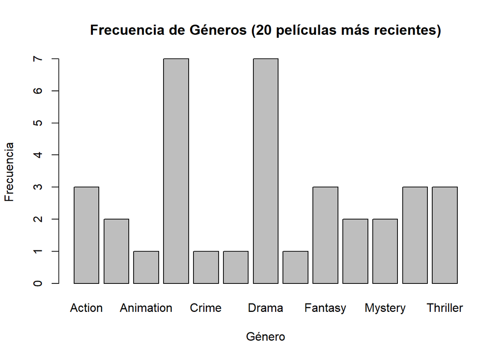

```r
barplot(frecuencia_generos, main = "Frecuencia de Géneros (20 películas más recientes)", xlab = "Género", ylab = "Frecuencia")
```

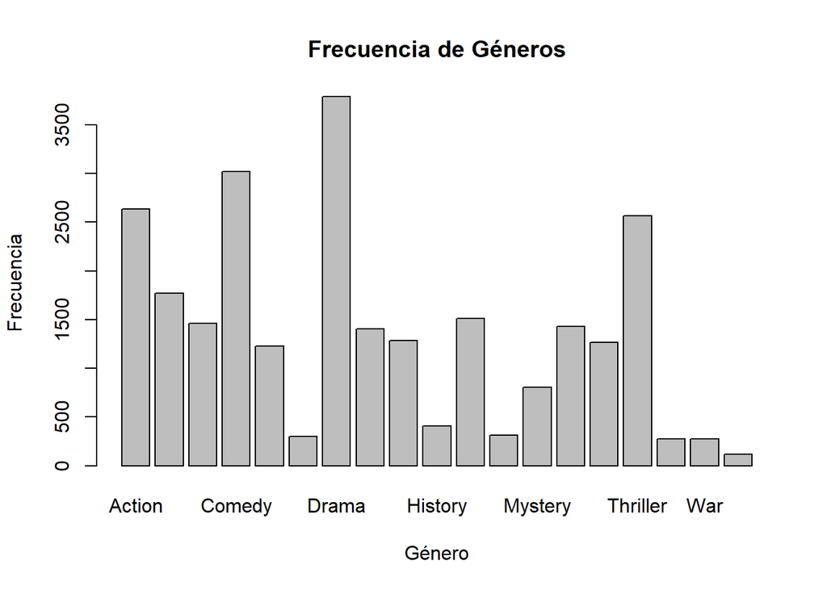

```r
genero_principal_20_totales <- head(frecuencia_generos_total, 20)
barplot(genero_principal_20_totales, main = "Frecuencia de Géneros", xlab = "Género", ylab = "Frecuencia")
```

## 4.7 ¿Las películas de qué género principal obtuvieron mayores ganancias?

```r
split_genres <- strsplit(movies$genres, "|", fixed = TRUE)
all_genres <- unlist(split_genres)
all_genres <- trimws(all_genres)
unique_genres <- unique(all_genres)
unique_genres <- na.omit(unique_genres)
enumerated_genres <- data.frame(Genre = unique_genres)

average_revenue_per_genre <- c()
for (genre in unique_genres) {
  genre_movies <- movies[grep(genre, movies$genres), ]
  average_revenue <- mean(genre_movies$revenue)
  average_revenue_per_genre <- c(average_revenue_per_genre, average_revenue)
}
enumerated_genres$AverageRevenue <- average_revenue_per_genre
enumerated_genres <- enumerated_genres[order(enumerated_genres$AverageRevenue, decreasing = TRUE), ]
print(enumerated_genres)
```

```
##              Genre AverageRevenue
## 14       Adventure   144148230.81
## 5          Fantasy   102606316.38
## 12 Science Fiction    97477679.34
## 11          Action    93733005.03
## 16          Family    85944224.10
## 15             War    68968291.39
## 3           Comedy    60131228.07
## 1        Animation    59564045.16
## 17           Crime    51121959.48
## 19         History    50945872.44
## 9          Romance    50566876.17
## 4         Thriller    50229311.67
## 13         Mystery    46361194.91
## 18         Western    45207915.50
## 2            Drama    43536829.80
## 8            Music    40958996.43
## 7           Horror    24316993.59
## 6      Documentary     3890503.37
## 10        TV Movie       67509.59
```

## 4.8 ¿La cantidad de actores influye en los ingresos de las películas? ¿se han hecho películas con más actores en los últimos años?

```r
correlation <- cor(movies$actorsAmount, movies$revenue)
cat("La correlación entre la cantidad de actores y las ganancias es:", correlation, "\n")
```

```
## La correlación entre la cantidad de actores y las ganancias es: -0.01955488
```

```r
cat("Esto sugiere que la cantidad de actores no influye en las ganancias de una película")
```

```
## Esto sugiere que la cantidad de actores no influye en las ganancias de una película
```

```r
movies$releaseDate <- as.Date(movies$releaseDate)
años_recientes <- movies[movies$releaseDate >= as.Date("2020-01-01"), ]
media_actores_ultimos_años <- mean(años_recientes$actorsAmount)
media_actores_total <- mean(movies$actorsAmount)
if (media_actores_ultimos_años > media_actores_total) {
  cat("En los últimos años se han hecho películas con más actores en promedio.\n")
  cat("Promedio de actores en los últimos años:", media_actores_ultimos_años, "\n")
  cat("Promedio de actores en el total de películas:", media_actores_total, "\n")
} else {
  cat("En los últimos años no se han hecho películas con más actores en promedio.\n")
  cat("Promedio de actores en los últimos años:", media_actores_ultimos_años, "\n")
  cat("Promedio de actores en el total de películas:", media_actores_total, "\n")
}
```

```
## En los últimos años se han hecho películas con más actores en promedio.
## Promedio de actores en los últimos años: 3032.114
## Promedio de actores en el total de películas: 2147.667
```

## 4.9 ¿Es posible que la cantidad de hombres y mujeres en el reparto influya en la popularidad y los ingresos de las películas?

```r
movies$castMenAmountInt <- as.integer(movies$castMenAmount)
movies$castWomenAmountInt <- as.integer(movies$castWomenAmount)
movies <- na.omit(movies[, c("popularity", "revenue", "castMenAmountInt", "castWomenAmountInt")])
cor_popularity_women <- cor(movies$popularity, movies$castWomenAmountInt)
cor_revenue_women <- cor(movies$revenue, movies$castWomenAmountInt)
cor_popularity_men <- cor(movies$popularity, movies$castMenAmountInt)
cor_revenue_men <- cor(movies$revenue, movies$castMenAmountInt)

cat("Correlación entre popularidad y cantidad de mujeres en el reparto:", cor_popularity_women, "\n")
```

```
## Correlación entre popularidad y cantidad de mujeres en el reparto: 0.0389395
```

```r
cat("Correlación entre ingresos y cantidad de mujeres en el reparto:", cor_revenue_women, "\n")
```

```
## Correlación entre ingresos y cantidad de mujeres en el reparto: 0.2900703
```

```r
cat("Correlación entre popularidad y cantidad de hombres en el reparto:", cor_popularity_men, "\n")
```

```
## Correlación entre popularidad y cantidad de hombres en el reparto: 0.002778599
```

```r
cat("Correlación entre ingresos y cantidad de hombres en el reparto:", cor_revenue_men, "\n")
```

```
## Correlación entre ingresos y cantidad de hombres en el reparto: -0.0601431
```

```r
cat("Esto sugiere que la cantidad de hombres y mujeres en el reparto no influye en la popularidad de las peliculas")
```

```
## Esto sugiere que la cantidad de hombres y mujeres en el reparto no influye en la popularidad de las peliculas
```

```r
cat("Por otro lado, la correlación entre ingresos y la cantidad de mujeres en el reparto es mayor que la correlación entre ingresos y la cantidad de hombres en el reparto, lo que sugiere que la cantidad de mujeres en el reparto puede influir levemente en los ingresos de las películas que la cantidad de hombres en el reparto")
```

[output not shown]

## 4.10 ¿Quiénes son los directores que hicieron las 20 películas mejor calificadas?

```r
movies <- read.csv("data/movies.csv")
vote_average_fixed <- as.numeric(movies$voteAvg)
vote_average_fixed <- na.omit(vote_average_fixed)
movies <- movies[order(vote_average_fixed, decreasing = TRUE), ]
top_20_movies <- head(movies, 20)
split_directors <- strsplit(top_20_movies$director, "|", fixed = TRUE)
all_directors <- unlist(split_directors)
all_directors <- trimws(all_directors)
unique_directors <- unique(all_directors)
fixed_directors <- na.omit(unique_directors)
enumerated_directors <- data.frame(Director = fixed_directors, Ranking = seq_along(fixed_directors))
print(enumerated_directors)
```

```
##               Director Ranking
## 1         Thomas Coven       1
## 2        Rebecca Sugar       2
## 3    Laurent Bouzereau       3
## 4         Kaku Arakawa       4
## 5       Christin Baker       5
## 6  Miguel Angel Zavala       6
## 7         Dave Bullock       7
## 8        Troy Adomitis       8
## 9          Victor Cook       9
## 10        Samuel Leong      10
## 11      Won Myeong-jun      11
## 12  Selena Quintanilla      12
## 13      Haruo Sotozaki      13
## 14     Ulises Valencia      14
## 15        Kim Nam-joon      15
## 16      Jeon Jung-kook      16
## 17       Kim Tae-hyung      17
## 18         Park Ji-min      18
## 19        Jung Ho-seok      19
## 20        Kim Seok-jin      20
## 21         Min Yoon-gi      21
```

## 4.11

```r
correlation <- cor(movies$budget, movies$revenue)
print(paste("La correlación entre presupuesto y ingresos es: ", correlation))
```

```
## [1] "La correlación entre presupuesto y ingresos es:  0.757454042495599"
```

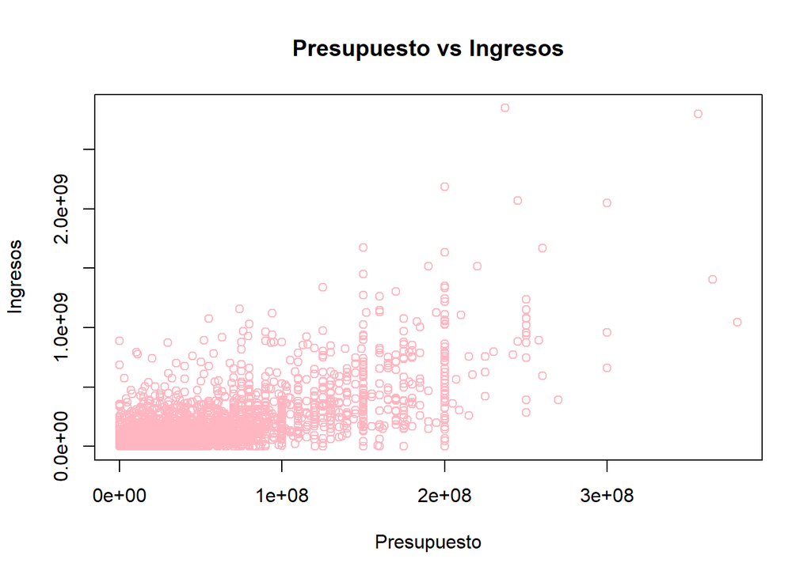

```r
#Diagrama de dispersión
moviesClean <- na.omit(movies[, c("budget", "revenue")])
dispersion <- plot(moviesClean$budget, moviesClean$revenue,
                   xlab = "Presupuesto", ylab = "Ingresos",
                   main = "Presupuesto vs Ingresos",
                   col = "lightpink")
```

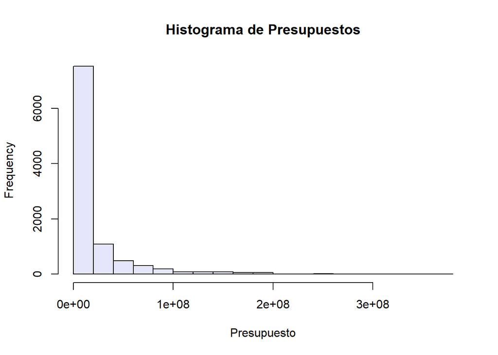

```r
#Histograma de presupuestos
histBudget <- hist(movies$budget, main = "Histograma de Presupuestos", xlab = "Presupuesto", col = "lavender")
```

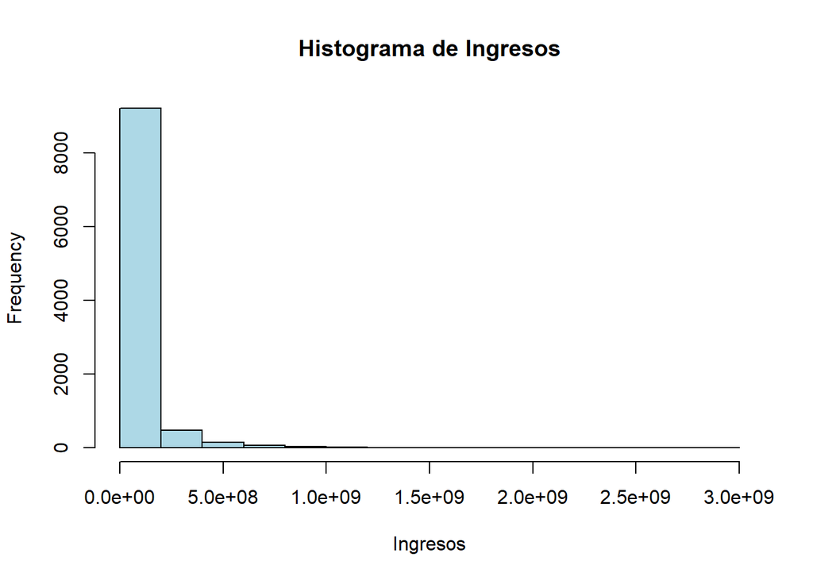

```r
#Histograma de ingresos
histRevenue <- hist(movies$revenue, main = "Histograma de Ingresos", xlab = "Ingresos", col = "lightblue")
```

```r
print("La correlación obtenida indica una fuerte correlación positiva entre los presupuestos y los ingresos")
```

```
## [1] "La correlación obtenida indica una fuerte correlación positiva entre los presupuestos y los ingresos"
```

```r
print("A pesar de esto, no se puede afirmar que los altos presupuestos causen altos ingresos o viceversa")
```

```
## [1] "A pesar de esto, no se puede afirmar que los altos presupuestos causen altos ingresos o viceversa"
```